# Task 1 - The overview

a) I'm using the python module from Bjørklund here because I want to write everything in python. I´ve done some modifcations to the data processing though, but should yield the same result.

```python
import bjorklund_extracts as be
# Extract station data
station_data = be.parse_h5_station_data()
```

```
Loading station  0  out of  202
Skipping file .DS_Store as it is not an .h5 file
Loading station  50  out of  202
Loading station  100  out of  202
Loading station  150  out of  202
Skipping file .cache as it is not an .h5 file
Loading station  200  out of  202
```

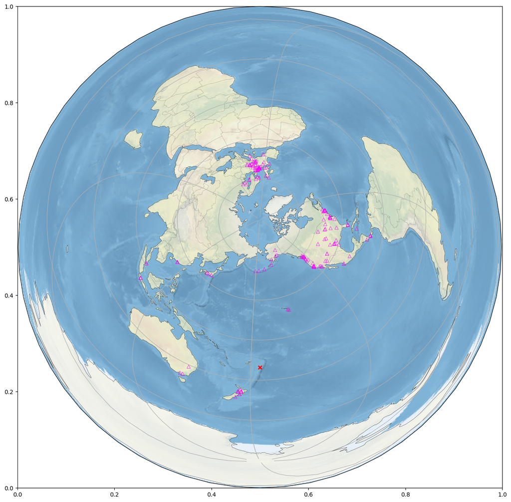

```
Smallest great circle distance is 2137.71km. Largest great circle distance is 17687.13km
```

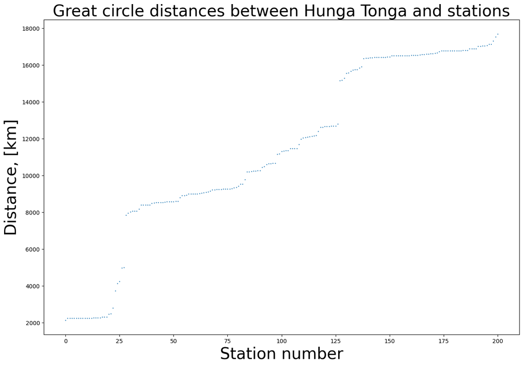

```python
# Plot the station map
be.plot_map(station_data, be.TONGA_LAT_LON)
# Calculate the distances
distances = be.circle_distance(station_data, be.TONGA_LAT_LON)
```

b) Based on the data analyzed above the shortest great circle distance is 2137.71km. Largest great circle distance is 17687.13km. c) See plot above.

# Task 2 - Data filtering

a) Plotting the three different FIR filter responses.

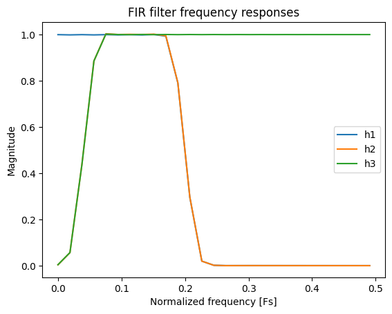

```python
import matias_project as ma
import matplotlib.pyplot as plt
import numpy as np

# Im taking the FFT of the three filters and plotting their magnitude responses
# this will give me their frequency responses
H1 = np.fft.rfft(ma.h1)
H2 = np.fft.rfft(ma.h2)
H3 = np.fft.rfft(ma.h3)
f = np.fft.rfftfreq(len(ma.h1))
fig, ax = plt.subplots()
ax.plot(f, np.abs(H1), label='h1')
ax.plot(f, np.abs(H2), label='h2')
ax.plot(f, np.abs(H3), label='h3')
ax.set_xlabel('Normalized frequency [Fs]')
ax.set_ylabel('Magnitude')
ax.set_title('FIR filter frequency responses')
ax.legend()
plt.show()
```

b) Checking my implmentation with numpy standard.

```python
# b) Checking my implmentation with numpy standard.
x = np.random.randn(1000)
np_convolved = np.convolve(x, ma.h1, mode='full')
ma_convolved = ma.convolve_signal_with_filter(h=ma.h1, x=x)
print("Are the two convolutions equal? ", np.allclose(np_convolved, ma_convolved))
```

```
Are the two convolutions equal?  True
```

c) Coding up a DFT method. See implementation in matias_project.py d) Using this method to plot the frequency spectrum of h1, h2 and h3.

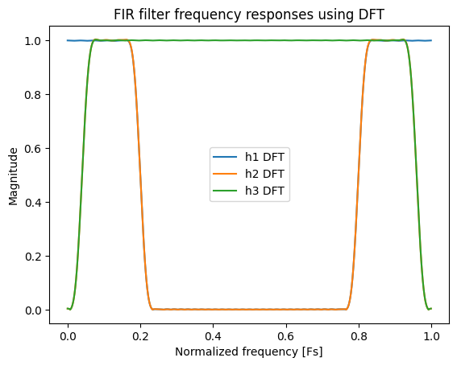

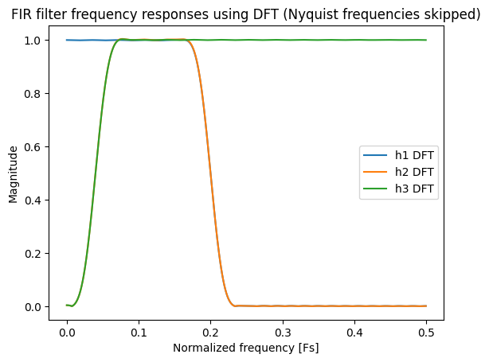

```python
N = 2048
H1_dft, freq_H1 = ma.dft(ma.h1, N=N)
H2_dft, freq_H2 = ma.dft(ma.h2, N=N)
H3_dft, freq_H3 = ma.dft(ma.h3, N=N)

fig, ax = plt.subplots()
ax.plot(freq_H1, np.abs(H1_dft), label='h1 DFT')
ax.plot(freq_H2, np.abs(H2_dft), label='h2 DFT')
ax.plot(freq_H3, np.abs(H3_dft), label='h3 DFT')
ax.set_xlabel('Normalized frequency [Fs]')
ax.set_ylabel('Magnitude')
ax.set_title('FIR filter frequency responses using DFT')
ax.legend()
plt.show()

# Same plot but skipping the nyquist(alias) frequencies
fig, ax = plt.subplots()
ax.plot(freq_H1[:N//2], np.abs(H1_dft[:N//2]), label='h1 DFT')
ax.plot(freq_H2[:N//2], np.abs(H2_dft[:N//2]), label='h2 DFT')
ax.plot(freq_H3[:N//2], np.abs(H3_dft[:N//2]), label='h3 DFT')
ax.set_xlabel('Normalized frequency [Fs]')
ax.set_ylabel('Magnitude')
ax.set_title('FIR filter frequency responses using DFT (Nyquist frequencies skipped)')
ax.legend()
plt.show()
```

f) Filtering all the data. As can be seen by modified "bjorklund_extracts.py" Ive chosen to use a Dataclass to hold all the data called StationData. I now convert this dataclass to StationDataFiltered, stored in "matias_project.py". Lastly I save this list of StationDaaFiltered to .pickle file to not have to do the computation again.

```python
station_data_filtered = list[ma.StationDataFiltered]()
for sd in station_data:
    station_data_filtered.append(ma.filter_station_data(sd))
ma.save_filtered_data(station_data_filtered)
```

g) I pivoted my code completly in this task. After spending hours almost writing the whole "plot_section" method (which was linked to in the task) for my StationDataFiltered class, and not getting any nice results. I realized that I should rather use the "obspy" library directly. After further investigation, I also saw that the data stored in the H5 files actually are "obspy" objects! Making this a lot easier. I choose to not re-write the code above, to keep some of the old work. But from here on, I actually import the data again into an "obspy.stream" instead, using the "ma.pase_h5_to_obspy_station_data". Everything just became a breeze.

I think the plot generated by the code is very similar as the plot 2C in the task description, however, it seems like I have slightly less data.

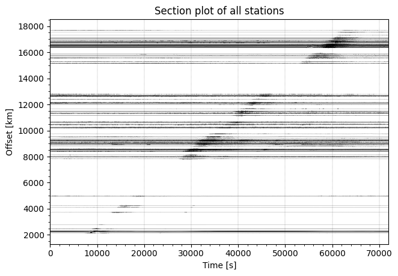

```python
import matias_project as ma
import numpy as np
stream = ma.parse_h5_to_obspy_station_data()
# Loop over the streams and apply filter h2
for tr in stream:
    tr.data = np.convolve(ma.h2, tr.data, mode="same")

# This code just got so much easier using obspy directly!
ma.plot_section(stream)
```

# Task 3 - Estimating the celerity of the globally propagating acoustic wave

a) First looping the stations, picking arival time in the metod "pick_arrival_time". Ive created a Dataclass objet called ArrivalTimePick in "matias_project.py" which I also save to a pickle file after the picking is done.

```python
# Since jupyter is non-interactive Ive ran this code below in a script
# and saved the output to a pickle file. I then load the pickle file here.
# stream = ma.parse_h5_to_obspy_station_data()
# arrival_time = ma.pick_arrival_time(stream)

import pathlib
import matias_project as ma
import pickle
arrival_time_loaded = ma.load_arrival_times(pathlib.Path("arrival_times_start_0_stop_200.pkl"))
```

```
Loaded 201 arrival time picks from arrival_times_start_0_stop_200.pkl
```

b) Loading inn the data and plotting it first.

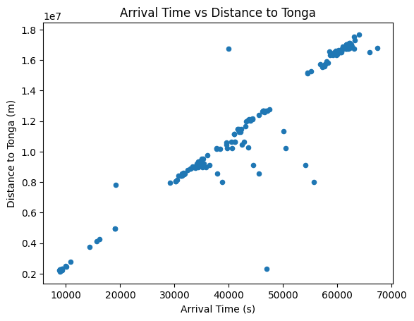

```python
# Plotting the arrival times vs distance
import pandas as pd
import matplotlib.pyplot as plt
df_arrival_time = pd.DataFrame(arrival_time_loaded)
df_arrival_time.plot.scatter(x="arrival_time", y="distance_to_tonga")
plt.ylabel("Distance to Tonga (m)")
plt.xlabel("Arrival Time (s)")
plt.title("Arrival Time vs Distance to Tonga")
plt.show()
```

As can be seen, some of the data seems like wrong pickes. I have choosen to remove some of these values.

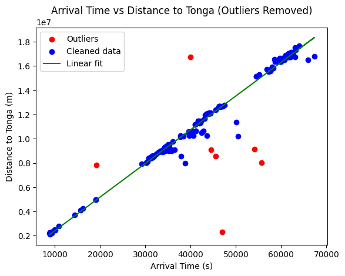

```
Estimated celerity velocity from linear fit: 277.79 m/s
```

```python
import numpy as np
# Removing some of the outliers based on visual inspection of the plot above
df_outliers = df_arrival_time[
    ((df_arrival_time["arrival_time"] < 23000) & (df_arrival_time["distance_to_tonga"] >0.6e7))
    | ((df_arrival_time["arrival_time"] < 50000) & (df_arrival_time["distance_to_tonga"] > 1.6e7))
    | ((df_arrival_time["arrival_time"] > 40000) & (df_arrival_time["distance_to_tonga"] < 0.95e7))

    ]

# Get the outliers for plotting
df_outliers_removed = df_arrival_time.drop(df_outliers.index)

# PLotting the cleaned data together with the removed outliers, and the linear fit of the cleaned data
fig, ax = plt.subplots()
ax.scatter(df_outliers["arrival_time"], df_outliers["distance_to_tonga"], label="Outliers", color='red')
ax.scatter(df_outliers_removed["arrival_time"], df_outliers_removed["distance_to_tonga"], color='blue', label="Cleaned data")
# Linear fit
m, b = np.polyfit(df_outliers_removed["arrival_time"], df_outliers_removed["distance_to_tonga"], 1)
ax.plot(df_outliers_removed["arrival_time"], m * df_outliers_removed["arrival_time"] + b, color='green', label="Linear fit")
ax.set_xlabel("Arrival Time (s)")
ax.set_ylabel("Distance to Tonga (m)")
ax.set_title("Arrival Time vs Distance to Tonga (Outliers Removed)")
ax.legend()
plt.show()
# Calculating the velocity from the slope of the linear fit
velocity = m    # in m/s
print(f"Estimated celerity velocity from linear fit: {velocity:.2f} m/s")
```

I'm pretty happy about this plot. I get an estimated celerity of 277.79m/s. On page 3 of Matoza et al. (2022) they mention that typical celerities of infrasound waves have group velocity between 250 and 290 m/s. I'm spot on in the middle here!